# Lesson 7 R Activity 1

Rick Davila

5/8/2020

## Lesson 7 - Install packages

#### Install necessary packages using library()

#### Perform data housekeeping - upload, name columns, display to make sure it reads properly, etc.

```r
knitr::opts_chunk$set(echo = TRUE)

library(e1071)
library(xtable)
library("xlsx") # Needed to read data
library(psych) # For geometric mean in Example 5.3
rm(list = ls())
```

#### Read data file (data-ex-5-1.xlsx)

```r
ex5_1 <- read.xlsx("data-ex-5-1.xlsx",
                   sheetIndex = 1,
                   colIndex = c(2,3),
                   as.data.frame = TRUE,
                   header = TRUE)
```

#### Assign labels to data columns using names() and attach() commands

```r
names(ex5_1) <- c("Usage", "Demand")
attach(ex5_1)
```

#### Output data to make sure it reads properly

```r
out <- as.data.frame(c(ex5_1))
colnames(out) <- c("Usage", "Demand")
tab <- (xtable(out, digits=c(0,0,2)))
print(tab, type="html")
```

|  | Usage | Demand |
| --- | --- | --- |
| 1 | 679 | 0.79 |
| 2 | 292 | 0.44 |
| 3 | 1012 | 0.56 |
| 4 | 493 | 0.79 |
| 5 | 582 | 2.70 |
| 6 | 1156 | 3.64 |
| 7 | 997 | 4.73 |
| 8 | 2189 | 9.50 |
| 9 | 1097 | 5.34 |
| 10 | 2078 | 6.85 |
| 11 | 1818 | 5.84 |
| 12 | 1700 | 5.21 |
| 13 | 747 | 3.25 |
| 14 | 2030 | 4.43 |
| 15 | 1643 | 3.16 |
| 16 | 414 | 0.50 |
| 17 | 354 | 0.17 |
| 18 | 1276 | 1.88 |
| 19 | 745 | 0.77 |
| 20 | 435 | 1.39 |
| 21 | 540 | 0.56 |
| 22 | 874 | 1.56 |
| 23 | 1543 | 5.28 |
| 24 | 1029 | 0.64 |
| 25 | 710 | 4.00 |
| 26 | 1434 | 0.31 |
| 27 | 837 | 4.20 |
| 28 | 1748 | 4.88 |
| 29 | 1381 | 3.48 |
| 30 | 1428 | 7.58 |
| 31 | 1255 | 2.63 |
| 32 | 1777 | 4.99 |
| 33 | 370 | 0.59 |
| 34 | 2316 | 8.19 |
| 35 | 1130 | 4.79 |
| 36 | 463 | 0.51 |
| 37 | 770 | 1.74 |
| 38 | 724 | 4.10 |
| 39 | 808 | 3.94 |
| 40 | 790 | 0.96 |
| 41 | 783 | 3.29 |
| 42 | 406 | 0.44 |
| 43 | 1242 | 3.24 |
| 44 | 658 | 2.14 |
| 45 | 1746 | 5.71 |
| 46 | 468 | 0.64 |
| 47 | 1114 | 1.90 |
| 48 | 413 | 0.51 |
| 49 | 1787 | 8.33 |
| 50 | 3560 | 14.94 |
| 51 | 1495 | 5.11 |
| 52 | 2221 | 3.85 |
| 53 | 1526 | 3.93 |

```r
# Output data structure and dimensions
str(ex5_1)
```

‘data.frame’: 53 obs. of 2 variables: $ Usage : num 679 292 1012 493 582 … $ Demand: num 0.79 0.44 0.56 0.79 2.7 3.64 4.73 9.5 5.34 6.85 …

```r
dim(ex5_1)
```

[1] 53 2

## Example 5.1 (p. 173-175)

#### Create scatterplot of data

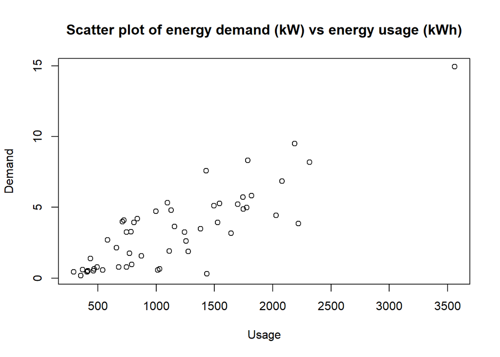

```r
plot(Usage,Demand, main = "Scatter plot of energy demand (kW) vs energy usage (kWh)")
```

#### Create linear model and display ANOVA table. Compare to least squares fit on p. 173 and ANOVA table on p. 175

```r
# Obtain regression estimates using lm command
model <- lm(Demand ~ Usage)
beta_0 <- model$coefficients[1]
beta_1 <- model$coefficients[2]

# show beta estimates, std. error, tvalues and p-values
xtable(model)
```

|  | Estimate | Std. Error | t value | Pr(>\|t\|) |
| --- | --- | --- | --- | --- |
| (Intercept) | -0.831303660 | 0.441612128 | -1.882429 | 6.548865e-02 |
| Usage | 0.003682843 | 0.000333897 | 11.029877 | 4.106229e-15 |

The equation for the linear regression model:
$$\hat{y} = (-0.8313037) + (0.0036828)x$$

```r
# ANOVA table
# summary(aov)
out <- anova(model)

xtable(out)
```

|  | Df | Sum Sq | Mean Sq | F value | Pr(>F) |
| --- | --- | --- | --- | --- | --- |
| Usage | 1 | 302.6331 | 302.633136 | 121.6582 | 4.106229e-15 |
| Residuals | 51 | 126.8660 | 2.487569 | NA | NA |

#### Create plot of R-Student values versus fitted values

```r
# Demand, given Usage
model <- lm(Demand ~ Usage)
beta_0 <- model$coefficients[1]
beta_1 <- model$coefficients[2]

# show beta estimates, std. error, tvalues and p-values
xtable(model)
```

|  | Estimate | Std. Error | t value | Pr(>\|t\|) |
| --- | --- | --- | --- | --- |
| (Intercept) | -0.831303660 | 0.441612128 | -1.882429 | 6.548865e-02 |
| Usage | 0.003682843 | 0.000333897 | 11.029877 | 4.106229e-15 |

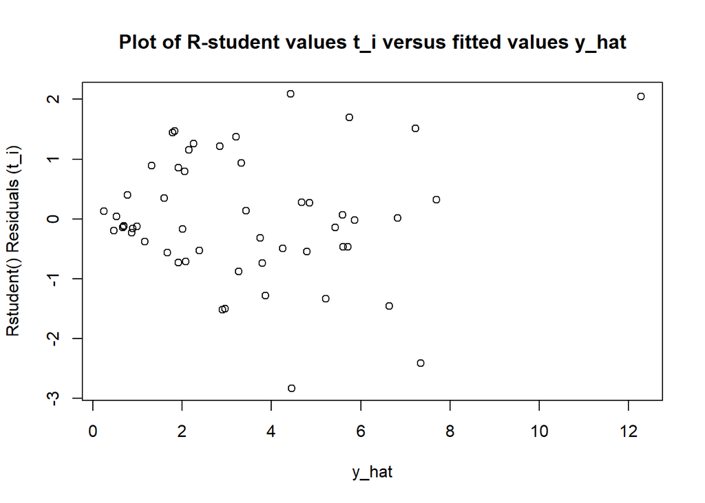

```r
# Calculate y_hat
y_hat <- beta_0 + beta_1*Usage

# Calculate R-Student residuals
residuals <- rstudent(model)

plot(y_hat, residuals, main='Plot of R-student values t_i versus fitted values y_hat', xlab = 'y_hat', ylab = 'Rstudent() Residuals (t_i)')
```

#### Transform and regress on y* = sqrt(y).Compare to least squares fit on p. 173

```r
y_star <- sqrt(Demand)

# Demand using sqrt transformation, given Usage
model.star <- lm(y_star ~ Usage)
beta_0 <- model.star$coefficients[1]
beta_1 <- model.star$coefficients[2]

# show beta estimates, std. error, tvalues and p-values
xtable(model)
```

|  | Estimate | Std. Error | t value | Pr(>\|t\|) |
| --- | --- | --- | --- | --- |
| (Intercept) | -0.831303660 | 0.441612128 | -1.882429 | 6.548865e-02 |
| Usage | 0.003682843 | 0.000333897 | 11.029877 | 4.106229e-15 |

```r
# Calculate y_hat
y_hat_star <- beta_0 + beta_1*Usage
```

#### Create plot of R-Student values versus fitted values of transformed model

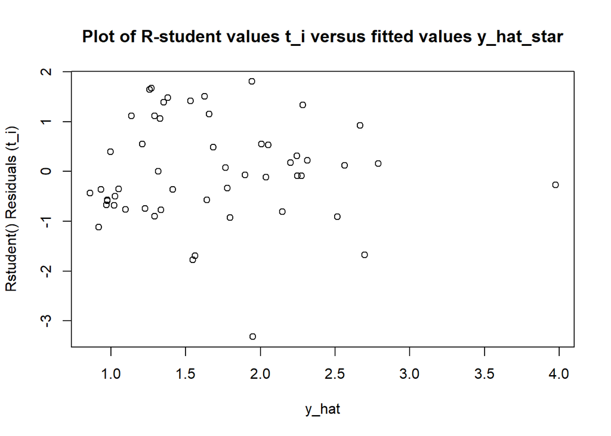

```r
# Calculate R-Student residuals
residuals <- rstudent(model.star)

plot(y_hat_star, residuals, main='Plot of R-student values t_i versus fitted values y_hat_star', xlab = 'y_hat', ylab = 'Rstudent() Residuals (t_i)')
```

## Example 5.3 (p. 184)

#### Perform Box-Cox transformation of Electric Utility data using boxcox() function. boxcox() outputs a range of x and y values. Plot those values and compare to p. 185. Why are the plots different?

```r
# create least sqares model
model <- lm(Demand ~ Usage)
library(MASS) # library containg boxcox
bc <- boxcox(Demand ~ Usage)
```

[figure not shown]

The boxcox() calcultes a log-likelhood for the y-axis versus the book using an approximate Confidence Interval for λ (based on the $SS_{Res})$.

```r
# extract lambda
best.lambda <- bc$x[which(bc$y==max(bc$y))]
```

The best lambda is $\lambda =0.5454545$

#### Transform y (Demand) using Box-Cox transformation Equation 5.1 on p. 182. Vary lambda values and compare SS_Residual to Table 5.7 on p. 185

```r
# power transformation procedure

# define power transformation function

pow_trans <- function(Lambda_In, ydata) {
# function to perform eqn 5.1 in e-book

n <- length(ydata)
#y_dot <- exp(sum(log(ydata))/n)
y_dot <- geometric.mean(ydata)


  if(Lambda_In == 0){
    y.lambda <- y_dot*log(ydata)

  } else {
    numerator <- ydata^(Lambda_In) - 1
    denominator <- Lambda_In*y_dot^(Lambda_In-1)
    y.lambda <- numerator/denominator

  }
result <- y.lambda
}

lambdaList <- c(-2, -1, -0.5, 0, 0.125, .25, .375, .5, best.lambda, 0.625, .75, 1, 2)
desired_length <- length(lambdaList)
SS_Res_out <- rep(NA, desired_length) # initialize a list

count <- 1
for (val in lambdaList) {

  ydata_trans <- pow_trans(val,Demand)
  model <- lm(ydata_trans ~ Usage)
  SS_Res_out[count] <- anova(model)$'Sum Sq'[2]
  count = count+1
}

List1 <- data.frame(lambdaList)
List2 <- data.frame(SS_Res_out)
out <- as.data.frame(c(List1,List2))
colnames(out) <- c("Lambda","$SS_{Res}$(Lambda)")
tab <- (xtable(out, digits=c(0, 3, 4)))
print(tab, type="html")
```

|  | Lambda | $SS_{Res}$(Lambda) |
| --- | --- | --- |
| 1 | -2.000 | 34100.6081 |
| 2 | -1.000 | 986.0341 |
| 3 | -0.500 | 291.5816 |
| 4 | 0.000 | 134.0935 |
| 5 | 0.125 | 118.1978 |
| 6 | 0.250 | 107.2054 |
| 7 | 0.375 | 100.2558 |
| 8 | 0.500 | 96.9493 |
| 9 | 0.545 | 96.6384 |
| 10 | 0.625 | 97.2887 |
| 11 | 0.750 | 101.6868 |
| 12 | 1.000 | 126.8660 |
| 13 | 2.000 | 1275.5606 |

[output not shown]